# Market Basket Analysis

Matteo Pancaldi

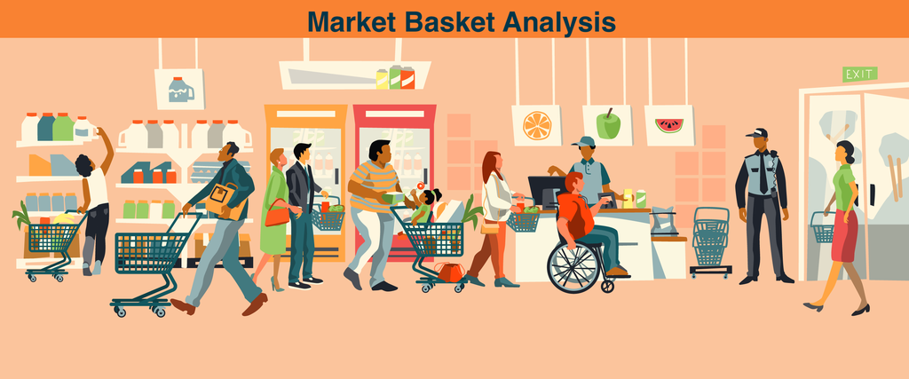

Association rules is an unsupervised learning technique which aims to describe and discover regularities between items in transaction data.

It is often used in **basket analysis** in sales to check if there are some general patterns in customers behaviour.

> If customer buys X, he also tends to buy Y

This is the statement that advice the sale department to improve knowledge of customers’ behavior.

The **main goal** of this analysis is to perform most common algorithm used to observe interesting patterns between consumer’s purchases.

# Dataset

The data used in this project contains information about Customers buying different **grocery items** at a Mall and you can find it on kaggle: https://www.kaggle.com/roshansharma/market-basket-optimization/version/1.

As the summary output shows, there are **7500 transactions and 119 products**.

```r
data<- read.transactions("Market_Basket_Optimisation.csv",
                         format = "basket", sep = ",", header = T)
summary(data)
```

```
## transactions as itemMatrix in sparse format with
##  7500 rows (elements/itemsets/transactions) and
##  119 columns (items) and a density of 0.03287171
##
## most frequent items:
## mineral water          eggs     spaghetti  french fries     chocolate
##          1787          1348          1306          1282          1229
##       (Other)
##         22386
##
## element (itemset/transaction) length distribution:
## sizes
##    1    2    3    4    5    6    7    8    9   10   11   12   13   14   15   16
## 1754 1358 1044  816  667  493  391  324  259  139  102   67   40   22   17    4
##   18   19
##    1    2
##
##    Min. 1st Qu.  Median    Mean 3rd Qu.    Max.
##   1.000   2.000   3.000   3.912   5.000  19.000
##
## includes extended item information - examples:
##              labels
## 1           almonds
## 2 antioxydant juice
## 3         asparagus
```

The output above anticipates already the most frequent items present in the data, let's try to present them on graph.

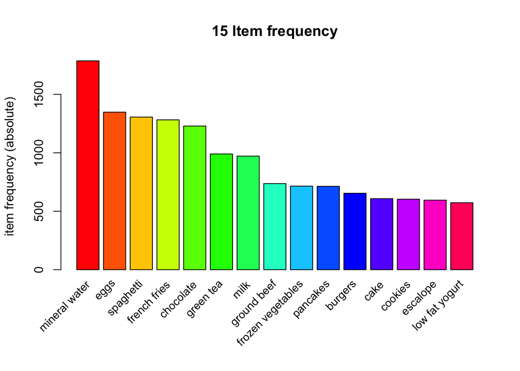

# Association rules

## Apriori

First of all, I have to create the rules using **Apriori Algorithm**.

There are three main indicators used to assess the quality of rules:

1. `Support`
2. `Confidence`
3. `lift`

In order to obtain any results to analysis the confidence had to be lowered, I decided to lower their values to **0.01 (support)** and **0.4 (confidence)**.

**17 rules were found.**

```r
rules = apriori(data, parameter = list(supp = 0.01, conf = 0.4))
```

```
## Apriori
##
## Parameter specification:
##  confidence minval smax arem  aval originalSupport maxtime support minlen
##         0.4    0.1    1 none FALSE            TRUE       5    0.01      1
##  maxlen target  ext
##      10  rules TRUE
##
## Algorithmic control:
##  filter tree heap memopt load sort verbose
##     0.1 TRUE TRUE  FALSE TRUE    2    TRUE
##
## Absolute minimum support count: 75
##
## set item appearances ...[0 item(s)] done [0.00s].
## set transactions ...[119 item(s), 7500 transaction(s)] done [0.00s].
## sorting and recoding items ... [75 item(s)] done [0.00s].
## creating transaction tree ... done [0.00s].
## checking subsets of size 1 2 3 4 done [0.00s].
## writing ... [17 rule(s)] done [0.00s].
## creating S4 object  ... done [0.00s].
```

### Visualization of rules

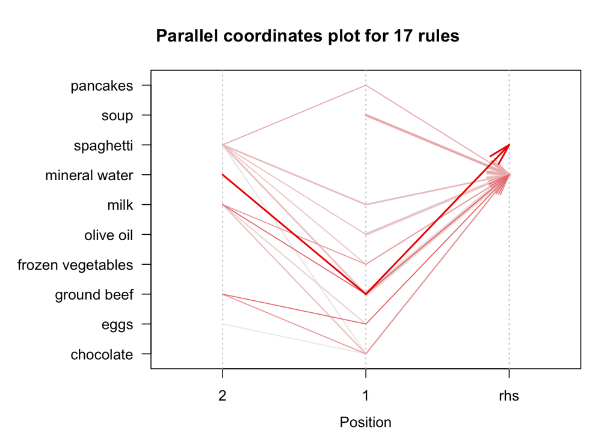

## Support

`Support` is the number of times a certain group of items appears in all orders, in other words, it is the **probability of appearing a transaction with all** items together.

$$Support(x) = \frac{Count(x)}{N}$$
where x represents an item and N represents the total number of transactions.

- 307 transactions on total, contained **ground beef and mineral water**.

```r
rules_support = sort(rules, by = "support", decreasing = TRUE)
inspect(head(rules_support))
```

```
##     lhs                            rhs             support    confidence
## [1] {ground beef}               => {mineral water} 0.04093333 0.4165536
## [2] {olive oil}                 => {mineral water} 0.02746667 0.4178499
## [3] {soup}                      => {mineral water} 0.02306667 0.4564644
## [4] {ground beef,spaghetti}     => {mineral water} 0.01706667 0.4353741
## [5] {ground beef,mineral water} => {spaghetti}     0.01706667 0.4169381
## [6] {chocolate,spaghetti}       => {mineral water} 0.01586667 0.4047619
##     coverage   lift     count
## [1] 0.09826667 1.748266 307
## [2] 0.06573333 1.753707 206
## [3] 0.05053333 1.915771 173
## [4] 0.03920000 1.827256 128
## [5] 0.04093333 2.394361 128
## [6] 0.03920000 1.698777 119
```

## Confidence

`Confidence` indicates the power of the rule, how often given rule is true.

It has maximum value of 1 and it is when customers **always buy item B with item A**.

$$Confidence(x -> y) = \frac{Support(x,y)}{Support(x)}$$
It is calculated as the support of item x and y divided by the support of item x.

```r
rules_confidence = sort(rules, by = "confidence", decreasing = TRUE)
inspect(head(rules_confidence))
```

```
##     lhs                         rhs             support    confidence
## [1] {eggs,ground beef}       => {mineral water} 0.01013333 0.5066667
## [2] {ground beef,milk}       => {mineral water} 0.01106667 0.5030303
## [3] {chocolate,ground beef}  => {mineral water} 0.01093333 0.4739884
## [4] {frozen vegetables,milk} => {mineral water} 0.01106667 0.4689266
## [5] {soup}                   => {mineral water} 0.02306667 0.4564644
## [6] {pancakes,spaghetti}     => {mineral water} 0.01146667 0.4550265
##     coverage   lift     count
## [1] 0.02000000 2.126469  76
## [2] 0.02200000 2.111207  83
## [3] 0.02306667 1.989319  82
## [4] 0.02360000 1.968075  83
## [5] 0.05053333 1.915771 173
## [6] 0.02520000 1.909736  86
```

## Lift

`Lift` can be seen as a measure of correlation of sorts and it is the indicator of **how strong the items are linked**.

- Lift > 1 -> products are positively correlated
- Lift < 1 -> products are negatively correlated
- Lift = 1 -> products are independent

It can be also defined as a measure of how much more likely one item is to be purchased relative to its typical purchase rate, given that you know another item has been purchased.

$$Lift(x -> y) = \frac{Confidence(x -> y)}{Support(y)}$$

In this case, it is more probable that a customer buys **ground beef, mineral water and spaghetti together** than just these products alone.

```r
rules_lift = sort(rules, by = "lift", decreasing = TRUE)
inspect(head(rules_lift))
```

```
##     lhs                            rhs             support    confidence
## [1] {ground beef,mineral water} => {spaghetti}     0.01706667 0.4169381
## [2] {eggs,ground beef}          => {mineral water} 0.01013333 0.5066667
## [3] {ground beef,milk}          => {mineral water} 0.01106667 0.5030303
## [4] {chocolate,ground beef}     => {mineral water} 0.01093333 0.4739884
## [5] {frozen vegetables,milk}    => {mineral water} 0.01106667 0.4689266
## [6] {soup}                      => {mineral water} 0.02306667 0.4564644
##     coverage   lift     count
## [1] 0.04093333 2.394361 128
## [2] 0.02000000 2.126469  76
## [3] 0.02200000 2.111207  83
## [4] 0.02306667 1.989319  82
## [5] 0.02360000 1.968075  83
## [6] 0.05053333 1.915771 173
```

# Spaghetti rules

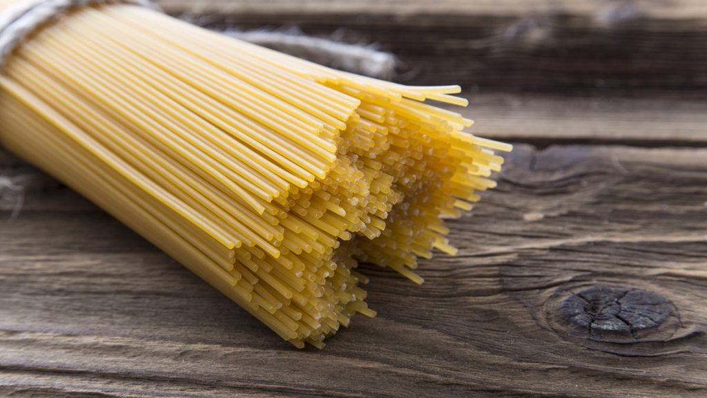

In order to go in depth with my analysis, I decided to concentrate my focus on a tipically product of my Italian country: `Spaghetti`.

In other word, I want to find out what products usually are bought together with the **famous type of pasta**.

The output below shows that most **strong rule** is the combination `frozen vegetables`,`olive oil`,`tomatoes` and `spaghetti`.

We can say that a combination of pasta taste has been identified.

It has the highest lift <- `4.835980`.

On other hand, **33 transactions** on total, contained **olive oil, tomatoes and spaghetti**.

```r
rules_spaghetti = apriori(data,
    parameter = list(supp = 0.002, conf = 0.6),
    appearance = list(default = "lhs", rhs = "spaghetti"),
    control = list(verbose = F)
  )
inspect(rules_spaghetti, linebreak = FALSE)
```

```
##      lhs                                          rhs         support
## [1]  {french wine,ground beef}                 => {spaghetti} 0.002400000
## [2]  {cereals,olive oil}                       => {spaghetti} 0.002000000
## [3]  {cereals,ground beef}                     => {spaghetti} 0.003066667
## [4]  {olive oil,tomatoes}                      => {spaghetti} 0.004400000
## [5]  {cooking oil,ground beef,mineral water}   => {spaghetti} 0.002133333
## [6]  {frozen vegetables,olive oil,tomatoes}    => {spaghetti} 0.002133333
## [7]  {frozen vegetables,ground beef,tomatoes}  => {spaghetti} 0.002000000
## [8]  {mineral water,olive oil,pancakes}        => {spaghetti} 0.002800000
## [9]  {frozen vegetables,ground beef,olive oil} => {spaghetti} 0.002133333
## [10] {frozen vegetables,ground beef,shrimp}    => {spaghetti} 0.002400000
##      confidence coverage    lift     count
## [1]  0.6206897  0.003866667 3.564451 18
## [2]  0.6818182  0.002933333 3.915495 15
## [3]  0.6764706  0.004533333 3.884785 23
## [4]  0.6111111  0.007200000 3.509444 33
## [5]  0.6666667  0.003200000 3.828484 16
## [6]  0.8421053  0.002533333 4.835980 16
## [7]  0.6250000  0.003200000 3.589204 15
## [8]  0.6000000  0.004666667 3.445636 21
## [9]  0.6400000  0.003333333 3.675345 16
## [10] 0.7500000  0.003200000 4.307044 18
```

## Visualization of Spaghetti rules

Let's try to plot the 10 rules created above.

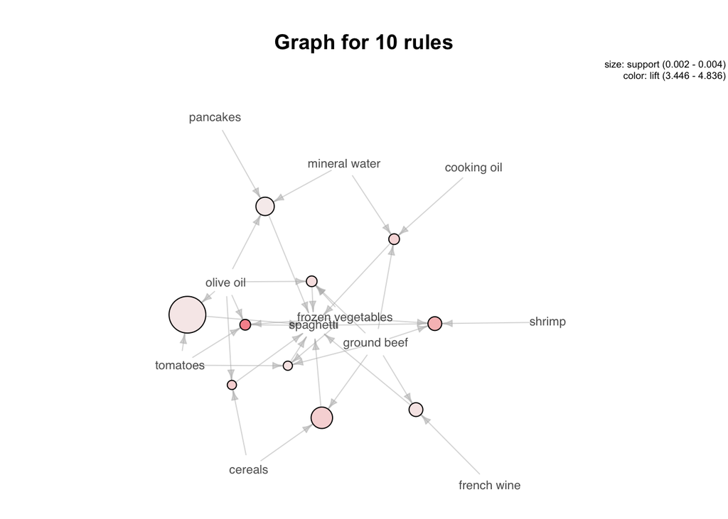

```r
plot(rules_spaghetti, method="graph", cex=0.7)
```

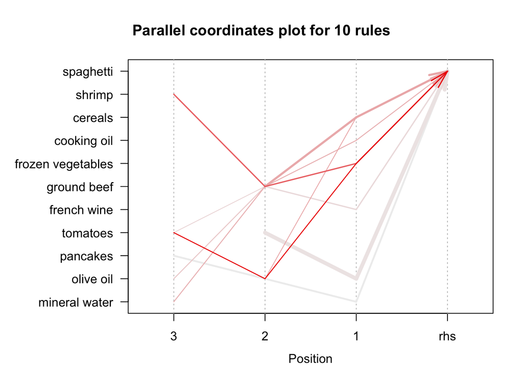

```r
plot(rules_spaghetti, method="paracoord", cex=0.7)
```

# Conclusion

In addition to the basic measures (support, confidence, lift) there are also **different measures** that can be conducted to get the deep knowledge of data:

- Jaccard Index
- Affinity measure

Those two measures will be calculated on the more frequent items.

## Dissimilarity

The possibility of calculating the dissimilarity of items using the **Jaccard index** still exists and it is based on probability calcus.

Checking the product dissimilarity, the most dissimilar products are `chocolate` and `green tea`, `green tea` and `milk` and `french fries` with `milk`.

```r
df<-data[,itemFrequency(data)>0.1]
J_index<-dissimilarity(df, which="items")
round(J_index,digits=3)
```

```
##               chocolate  eggs french fries green tea  milk mineral water
## eggs              0.893
## french fries      0.885 0.884
## green tea         0.914 0.911        0.896
## milk              0.877 0.889        0.914     0.928
## mineral water     0.849 0.861        0.910     0.909 0.850
## spaghetti         0.869 0.885        0.913     0.905 0.868         0.831
```

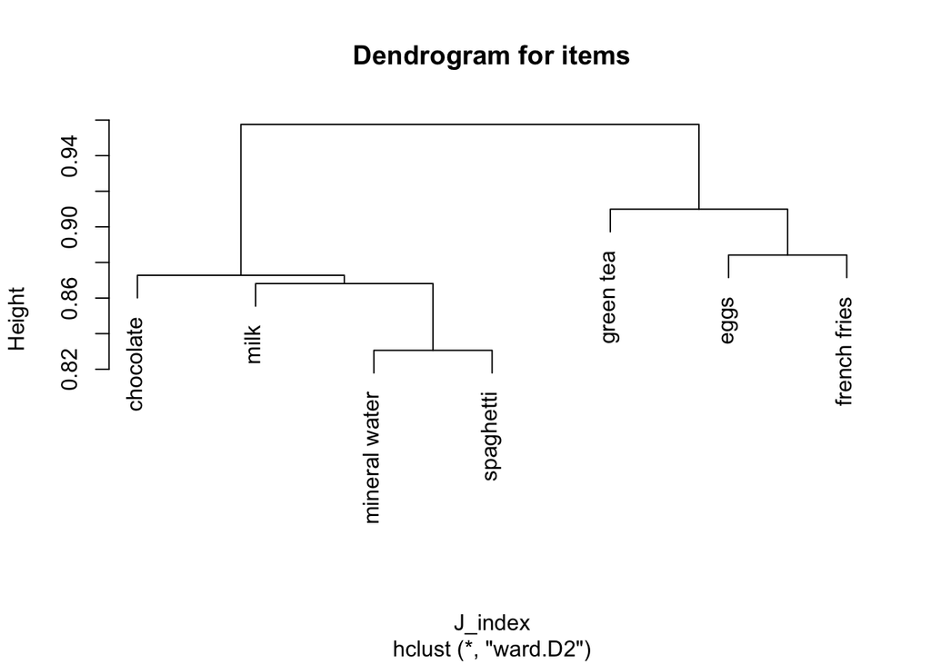

```r
plot(hclust(J_index, method = "ward.D2"), main = "Dendrogram for items")
```

## Similarity

On the contrary to Jaccard Index, let’s use **Affinity measure** in order to discover similarity of items.

```r
sim<-affinity(df)
round(sim, digits = 4)
```

```
## An object of class "ar_similarity"
##               chocolate   eggs french fries green tea   milk mineral water
## chocolate        0.0000 0.1070       0.1145    0.0861 0.1230        0.1507
## eggs             0.1070 0.0000       0.1158    0.0890 0.1106        0.1388
## french fries     0.1145 0.1158       0.0000    0.1040 0.0857        0.0898
## green tea        0.0861 0.0890       0.1040    0.0000 0.0721        0.0912
## milk             0.1230 0.1106       0.0857    0.0721 0.0000        0.1501
## mineral water    0.1507 0.1388       0.0898    0.0912 0.1501        0.0000
## spaghetti        0.1312 0.1151       0.0869    0.0949 0.1322        0.1694
##               spaghetti
## chocolate        0.1312
## eggs             0.1151
## french fries     0.0869
## green tea        0.0949
## milk             0.1322
## mineral water    0.1694
## spaghetti        0.0000
## Slot "method":
## [1] "Affinity"
```